# Chicago Meteorological Data

Hank Magan

8/31/2021

Abstract

This document provides a preliminary analysis on data supplied by AlternativeAire, containing a variety of meteorological data from the city of Chicago every day from January 1987 to December 2005.

## Data Demographics

Before manipulating the data, it is important to explore it to gain an understanding of the data demographics. To do this, we look at the basic structure of the data, the number of entries (rows) and columns, and a general, statistical summary. By doing this, we gain an understanding of the size of the data, as well as what it describes.

```r
str(chicago)
```

```
## 'data.frame':    6940 obs. of  9 variables:
##  $ indx      : int  1 2 3 4 5 6 7 8 9 10 ...
##  $ city      : chr  "chic" "chic" "chic" "chic" ...
##  $ tmpd      : num  31.5 33 33 29 32 40 34.5 29 26.5 32.5 ...
##  $ dptp      : num  31.5 29.9 27.4 28.6 28.9 ...
##  $ date      : chr  "1/1/87" "1/2/87" "1/3/87" "1/4/87" ...
##  $ pm25tmean2: num  NA NA NA NA NA NA NA NA NA NA ...
##  $ pm10tmean2: num  34 NA 34.2 47 NA ...
##  $ o3tmean2  : num  4.25 3.3 3.33 4.38 4.75 ...
##  $ no2tmean2 : num  20 23.2 23.8 30.4 30.3 ...
```

```r
dim(chicago)
```

```
## [1] 6940    9
```

```r
summary(chicago)
```

```
##       indx          city                tmpd             dptp
##  Min.   :   1   Length:6940        Min.   :-16.00   Min.   :-25.62
##  1st Qu.:1736   Class :character   1st Qu.: 35.00   1st Qu.: 27.00
##  Median :3470   Mode  :character   Median : 51.00   Median : 39.88
##  Mean   :3470                      Mean   : 50.31   Mean   : 40.34
##  3rd Qu.:5205                      3rd Qu.: 67.00   3rd Qu.: 55.75
##  Max.   :6940                      Max.   : 92.00   Max.   : 78.25
##                                    NA's   :1        NA's   :2
##      date             pm25tmean2      pm10tmean2        o3tmean2
##  Length:6940        Min.   : 1.70   Min.   :  2.00   Min.   : 0.1528
##  Class :character   1st Qu.: 9.70   1st Qu.: 21.50   1st Qu.:10.0729
##  Mode  :character   Median :14.66   Median : 30.28   Median :18.5218
##                     Mean   :16.23   Mean   : 33.90   Mean   :19.4355
##                     3rd Qu.:20.60   3rd Qu.: 42.00   3rd Qu.:27.0010
##                     Max.   :61.50   Max.   :365.00   Max.   :66.5875
##                     NA's   :4447    NA's   :242
##    no2tmean2
##  Min.   : 6.158
##  1st Qu.:19.654
##  Median :24.556
##  Mean   :25.232
##  3rd Qu.:30.139
##  Max.   :62.480
##
```

## Data Cleanup

Raw, untouched data containing discrepancies is not entirely useful to us. As such, we can go through certain procedures to both make the data more readable and to make statistical inferencing easier.

Some of the included data is irrelevant in our analysis (namely the index and city columns), so it may be removed.

```r
chicago$indx <- NULL
chicago$city <- NULL
```

This leaves us with the following:

```
## [1] "tmpd"       "dptp"       "date"       "pm25tmean2" "pm10tmean2"
## [6] "o3tmean2"   "no2tmean2"
```

As you can see, some of the naming used in the data is either ambiguous and difficult to interpret or can be made more readable. To fix this, we can simply rename all the columns to the names seen below.

```r
names(chicago) <- c("Temp", "Dewpoint", "Date", "PM25", "PM10", "O3", "NO3")
```

Additionally, we can use a function from the *lubridate* package to work with a standardized date format (YYYY-MM-DD).

```r
chicago$Date <- mdy(chicago$Date)
head(chicago)
```

```
##   Temp Dewpoint       Date PM25     PM10       O3      NO3
## 1 31.5   31.500 1987-01-01   NA 34.00000 4.250000 19.98810
## 2 33.0   29.875 1987-01-02   NA       NA 3.304348 23.19099
## 3 33.0   27.375 1987-01-03   NA 34.16667 3.333333 23.81548
## 4 29.0   28.625 1987-01-04   NA 47.00000 4.375000 30.43452
## 5 32.0   28.875 1987-01-05   NA       NA 4.750000 30.33333
## 6 40.0   35.125 1987-01-06   NA 48.00000 5.833333 25.77233
```

Lastly, we want to normalize certain categories of data so that it is easily workable and interpretable. In order to do this, missing entries in the data must be rectified beforehand. One way to do this is to apply the mean of all data in the column to any empty spots. This technique was applied to the PM25 and PM10 columns, as shown below.

```r
PM25_mean <- mean(chicago$PM25, na.rm=TRUE)
PM10_mean <- mean(chicago$PM10, na.rm=TRUE)
chicago$PM25 <- ifelse(is.na(chicago$PM25), PM25_mean, chicago$PM25)
chicago$PM10 <- ifelse(is.na(chicago$PM10), PM10_mean, chicago$PM10)
```

Now that there are no empty entries, the data can be properly normalized.

```r
chicago$PM25 <- chicago$PM25 / max(chicago$PM25)
chicago$PM10 <- chicago$PM10 / max(chicago$PM10)
head(chicago)
```

```
##   Temp Dewpoint       Date     PM25       PM10       O3      NO3
## 1 31.5   31.500 1987-01-01 0.263918 0.09315068 4.250000 19.98810
## 2 33.0   29.875 1987-01-02 0.263918 0.09286358 3.304348 23.19099
## 3 33.0   27.375 1987-01-03 0.263918 0.09360731 3.333333 23.81548
## 4 29.0   28.625 1987-01-04 0.263918 0.12876712 4.375000 30.43452
## 5 32.0   28.875 1987-01-05 0.263918 0.09286358 4.750000 30.33333
## 6 40.0   35.125 1987-01-06 0.263918 0.13150685 5.833333 25.77233
```

As you can see, our remaining data is much cleaner than what we started with. Now that nomenclature has been clarified and data has been cleansed, statistical analysis may now take place.

## Data Visualization

A variety of transformations and graphs may be observed to gain a better understanding of the data that was just cleansed.

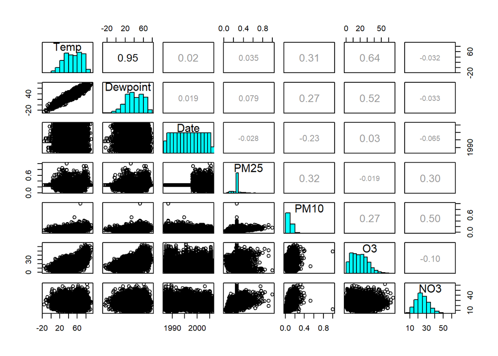

```r
pairs(chicago,upper.panel=panel.cor,diag.panel=panel.hist)
```

Taking a closer look at some of the data can reveal a little more. For example consider the histogram of temperatures:

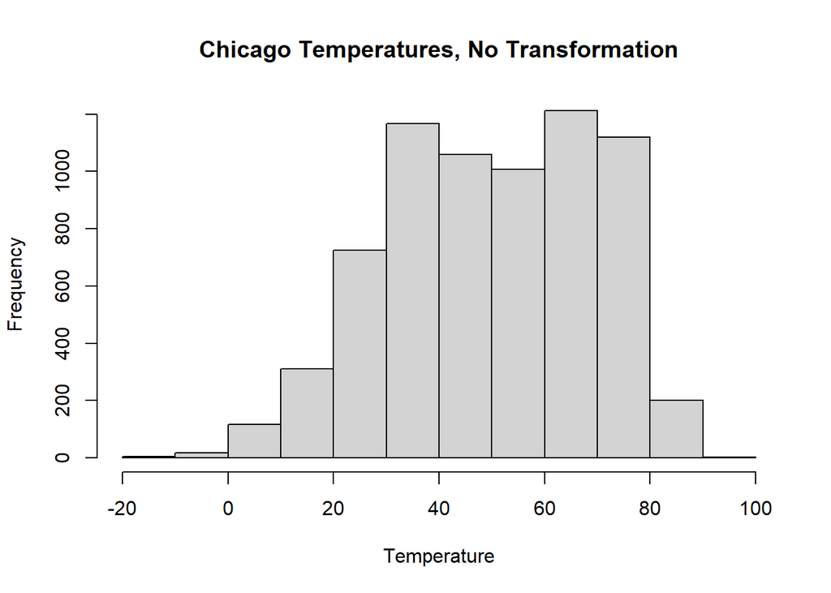

```r
hist(chicago$Temp, main="Chicago Temperatures, No Transformation", xlab="Temperature")
```

This can be transformed using a Rank Z transformation to attain a more normally distributed histogram, like so:

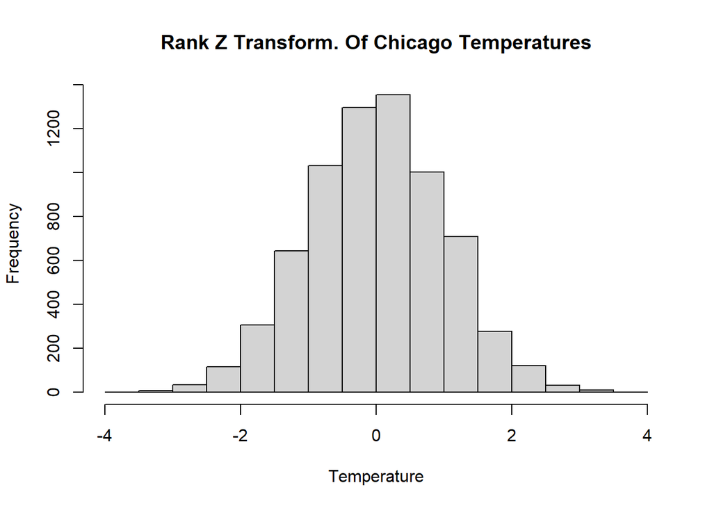

```r
chicago$Temp <- rz.transform(chicago$Temp) # Rank Z transformation
hist(chicago$Temp, main="Rank Z Transform. Of Chicago Temperatures", xlab="Temperature")
```

Here are some more examples of the same processing, both garnering similar results:

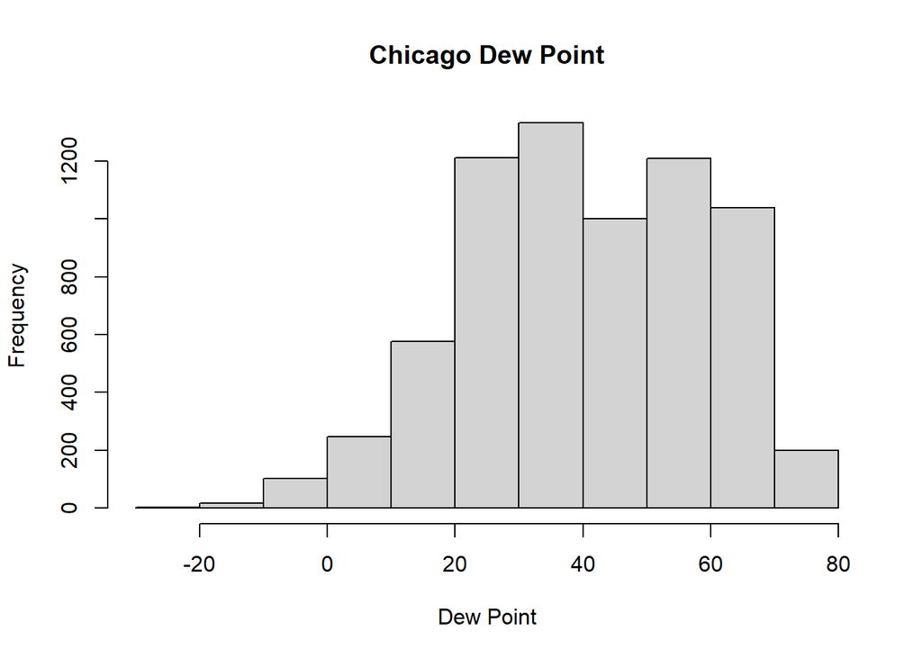

```r
hist(chicago$Dewpoint, main="Chicago Dew Point", xlab="Dew Point")
```

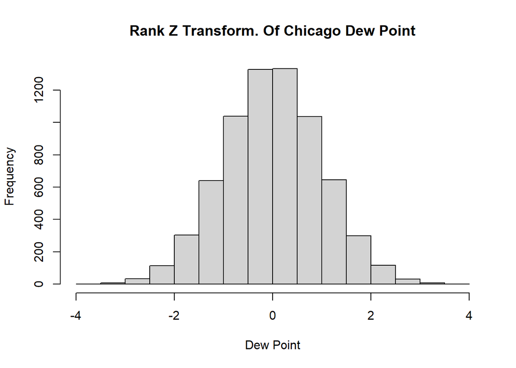

```r
chicago$Dewpoint <- rz.transform(chicago$Dewpoint)
hist(chicago$Dewpoint, main="Rank Z Transform. Of Chicago Dew Point", xlab="Dew Point")
```

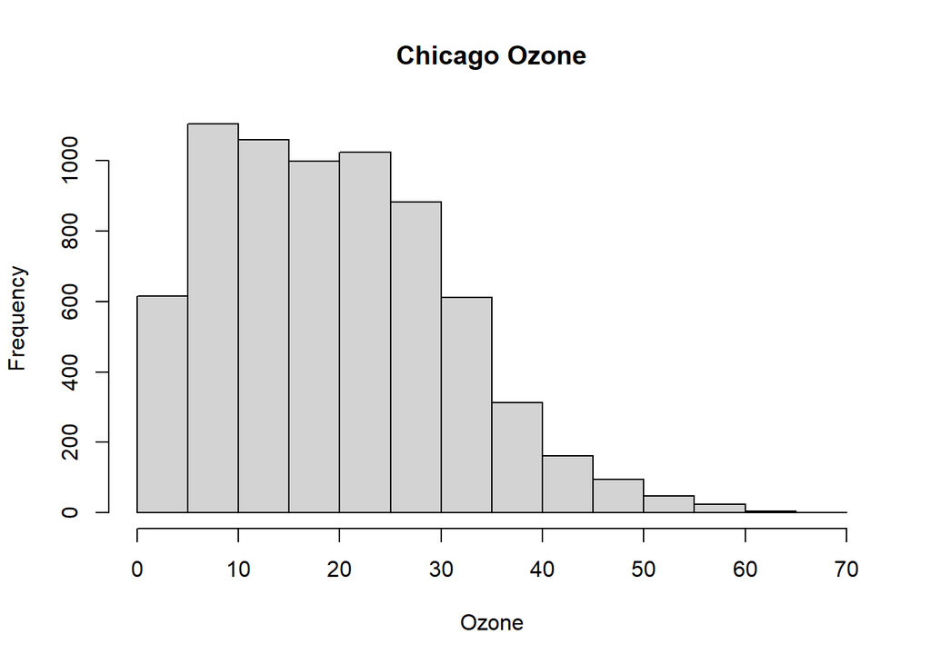

```r
hist(chicago$O3, main="Chicago Ozone", xlab="Ozone")
```

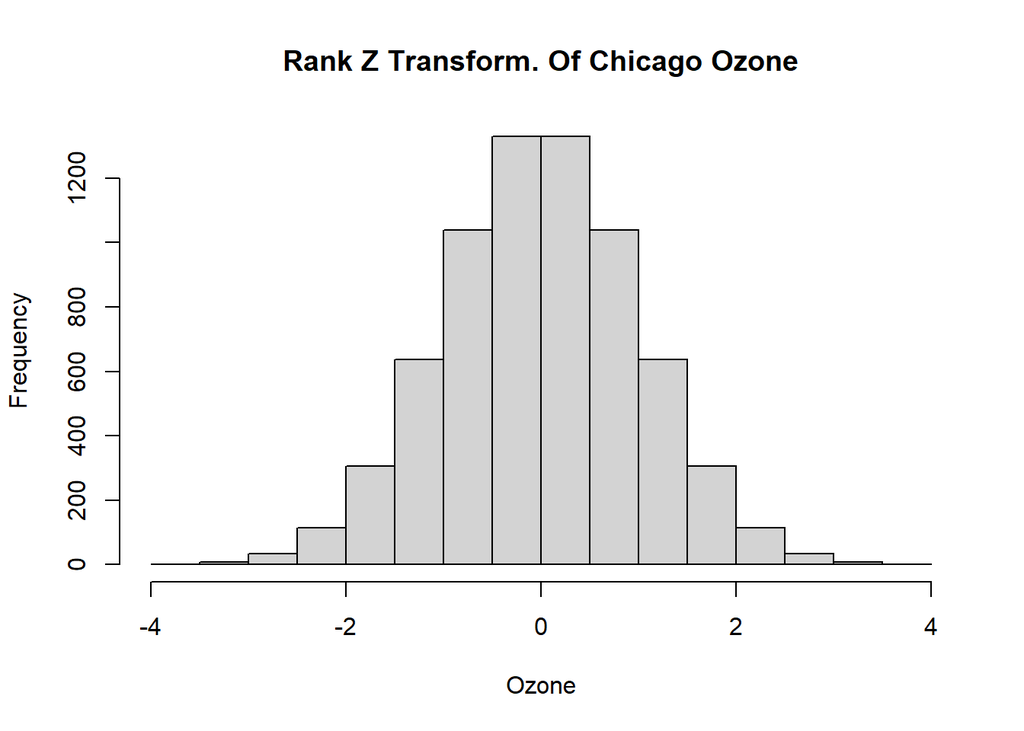

```r
chicago$O3 <- rz.transform(chicago$O3)
hist(chicago$O3, main="Rank Z Transform. Of Chicago Ozone", xlab="Ozone")
```

Additionally, correlations can be observed between points of data, such as the very strong positive correlation between temperature and dew point:

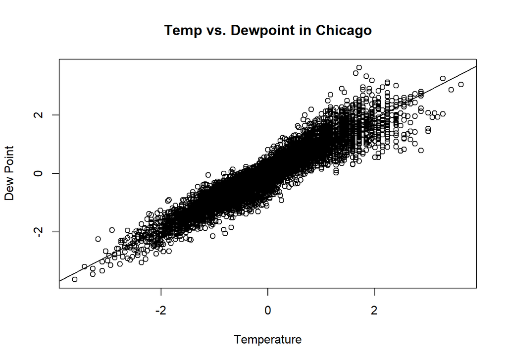

```r
plot(chicago$Temp, chicago$Dewpoint, main="Temp vs. Dewpoint in Chicago", xlab="Temperature", ylab="Dew Point")
fitline <- lm(chicago$Temp~chicago$Dewpoint) # linear reg. line
abline(fitline)
```

The first several rows may be revisited to observe the effects of the transformations of the data itself, as shown below.

```
##         Temp   Dewpoint       Date     PM25       PM10        O3      NO3
## 1 -0.8875481 -0.4013812 1987-01-01 0.263918 0.09315068 -1.512587 19.98810
## 2 -0.8026273 -0.5034586 1987-01-02 0.263918 0.09286358 -1.745096 23.19099
## 3 -0.8026273 -0.6536607 1987-01-03 0.263918 0.09360731 -1.735247 23.81548
## 4 -1.0333483 -0.5772509 1987-01-04 0.263918 0.12876712 -1.488649 30.43452
## 5 -0.8595128 -0.5634370 1987-01-05 0.263918 0.09286358 -1.410695 30.33333
## 6 -0.4340321 -0.1933769 1987-01-06 0.263918 0.13150685 -1.218909 25.77233
```